# **PRÁCTICA 2 VISUALIZACIÓN DE DATOS**

**José María Arroyo Sánchez**

La presente práctica se enfocó en explorar y analizar de manera exhaustiva un conjunto de datos relacionados con carreras de Fórmula 1 (sprint) mediante técnicas avanzadas de visualización, con el propósito de extraer información valiosa y comprender mejor los factores que influyen en el rendimiento de los conductores y equipos.

```python
import warnings
import pandas as pd
import matplotlib.pyplot as plt
import seaborn as sns
import numpy as np
import plotly.express as px
import plotly.graph_objects as go
from scipy.stats import bartlett, f_oneway
warnings.filterwarnings("ignore", category=UserWarning, module="seaborn")
warnings.filterwarnings("ignore", category=FutureWarning, module="seaborn._oldcore")
warnings.filterwarnings("ignore", category=FutureWarning, module="pandas")
```

```python
# Subida del archivo CSV
from google.colab import files
uploaded = files.upload()
```

Upload widget is only available when the cell has been executed in the current browser session. Please rerun this cell to enable.

```
Saving circuits.csv to circuits (2).csv
Saving constructors.csv to constructors (2).csv
Saving drivers.csv to drivers (2).csv
Saving races.csv to races (2).csv
Saving results.csv to results (2).csv
Saving sprint_results.csv to sprint_results (2).csv
Saving status.csv to status (2).csv
```

```python
#  Leer archivos CSV y crear DataFrames con la información los datos del archivo CSV.
races = pd.read_csv('races.csv')
race_results = pd.read_csv('results.csv')
sprints = pd.read_csv('sprint_results.csv')
circuits = pd.read_csv('circuits.csv')
drivers = pd.read_csv('drivers.csv')
teams = pd.read_csv('constructors.csv')
statuses = pd.read_csv('status.csv')
```

```python
# Unión de datos
sprint_details = pd.merge(sprints, races[['raceId', 'circuitId', 'name', 'date']], on='raceId')
sprint_details = pd.merge(sprint_details, circuits[['circuitId', 'name', 'location']], left_on='circuitId', right_on='circuitId')
sprint_details = pd.merge(sprint_details, race_results[['raceId', 'positionOrder', 'driverId', 'grid', 'points']], on=['raceId', 'driverId'])
sprint_details = pd.merge(sprint_details, drivers[['driverId', 'number', 'code', 'forename', 'surname', 'dob', 'nationality']], on='driverId')
sprint_details = pd.merge(sprint_details, teams[['constructorId', 'name', 'nationality']], left_on='constructorId', right_on='constructorId')
sprint_details = pd.merge(sprint_details, statuses[['statusId', 'status']], left_on='statusId', right_on='statusId')
sprint_details['fullname'] = sprint_details['forename'] + ' ' + sprint_details['surname']
```

```python
# Procesamiento adicional de datos
sprint_details['dob'] = pd.to_datetime(sprint_details['dob'])
sprint_details['age'] = ((pd.to_datetime(sprint_details['date']) - sprint_details['dob']).dt.days / 365.25).round()
sprint_details['Age group'] = pd.cut(sprint_details['age'], bins=[0, 25, 29, 33, float('inf')], labels=['Under 25', '25-28', '29-32', 'Over 32'])
```

**GRAFICO 1:** ¿Existe alguna relación entre la edad de los conductores, los puntos ganados y su posición en la parrilla?

```python
# Gráfico 1: Relación 3D entre Edad, Puntos y Posición en el Grid
fig = px.scatter_3d(sprint_details, x='age', y='points_x', z='grid_x', color='points_x', size='points_x',
                    labels={'grid_x': 'Posición en el Grid'})
fig.update_layout(title='Relación 3D entre Edad, Puntos y Posición en el Grid')
fig.show()
```

[interactive chart not shown]

**GRÁFICO 2:** ¿Cómo varían los puntos ganados por los conductores de diferentes nacionalidades?

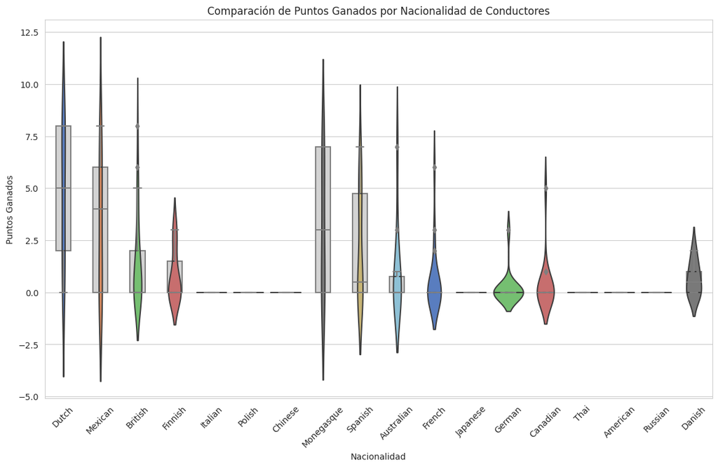

```python
# Gráfico 2: Diagrama de violín y de caja para comparar los puntos ganados por nacionalidad.
plt.figure(figsize=(14, 8))
sns.violinplot(x='nationality_x', y='points_x', data=sprint_details, inner='quartile', palette='muted')
sns.boxplot(x='nationality_x', y='points_x', data=sprint_details, color='lightgray', width=0.4)
plt.title('Comparación de Puntos Ganados por Nacionalidad de Conductores')
plt.xlabel('Nacionalidad')
plt.ylabel('Puntos Ganados')
plt.xticks(rotation=45)
plt.show()
```

**GRÁFICO 3:** ¿Se da una relación entre la posición en el grid y los puntos ganados?

```python
# Gráfico 3: Relación entre los puntos y la posición en el grid.
fig = px.scatter(sprint_details, x='grid_x', y='points_x', color='points_x', marginal_y='histogram',
                 marginal_x='box', trendline='ols', title='Relación entre Puntos y Posición en el Grid')
fig.update_layout(xaxis_title='Posición en el Grid', yaxis_title='Puntos Ganados')
fig.show()
```

[interactive chart not shown]

**GRÁFICO 4:** ¿Cuáles son los circuitos donde se han obtenido más puntos?

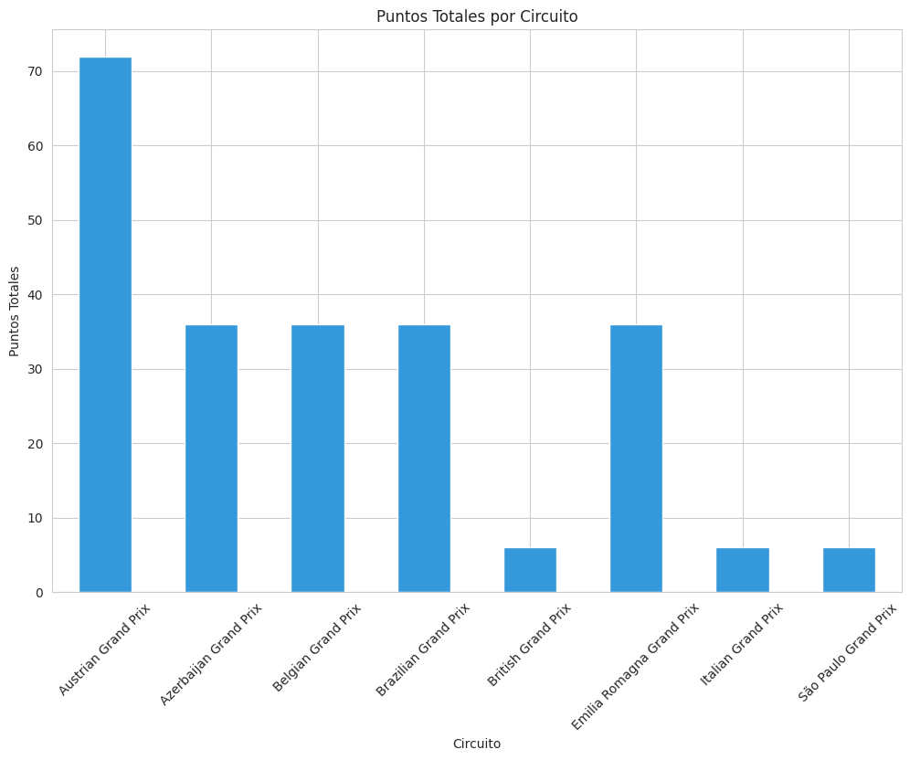

```python
# Gráfico 4: Barras para ver los puntos ganados por circuito.
plt.figure(figsize=(12, 8))
moderate_blue = '#3498DB'  # Un tono de azul más moderado
sprint_details.groupby('name_x')['points_x'].sum().plot(kind='bar', color=moderate_blue)
plt.title('Puntos Totales por Circuito')
plt.xlabel('Circuito')
plt.ylabel('Puntos Totales')
plt.xticks(rotation=45)
plt.show()
```

**GRÁFICO 5:** ¿Cómo ha evolucionado el rendimiento de los conductores a lo largo de las carreras?

```python
# Gráfico 5: Líneas (dinámico) para ver la evolución de los puntos a lo largo del tiempo.
fig = go.Figure()
for driver in sprint_details['fullname'].unique():
    data = sprint_details[sprint_details['fullname'] == driver]
    fig.add_trace(go.Scatter(x=data['date'], y=data['points_x'], mode='lines+markers', name=driver))

fig.update_layout(title='Evolución de Puntos por Conductor a lo Largo del Tiempo')
fig.update_xaxes(tickangle=-45)  # Rotar el eje x en 45 grados
fig.show()
```

[interactive chart not shown]

**GRÁFICO 6:** ¿Cómo se distribuyen los puntos entre los diferentes equipos constructores?

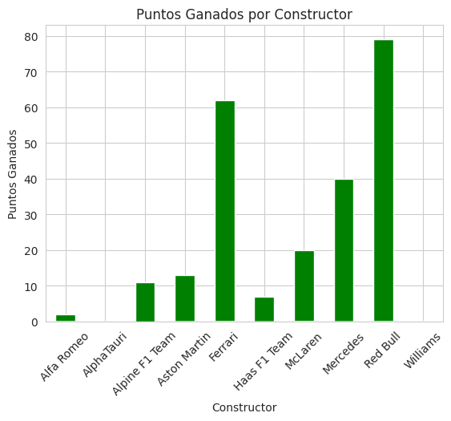

```python
# Gráfico 6: Barras para ver los puntos ganados por los constructores.
plt.figure(figsize=(14, 8))
constructor_names = sprint_details.groupby('constructorId')['name'].first()
sprint_details['constructorName'] = sprint_details['constructorId'].map(constructor_names)

# Crear una columna 'color' con el color verde para todos los constructores
sprint_details['color'] = 'green'

ax = sprint_details.groupby(['constructorName', 'constructorId'])['points_x'].sum().unstack().plot(kind='bar', stacked=True, color=sprint_details['color'])
plt.title('Puntos Ganados por Constructor')
plt.xlabel('Constructor')
plt.ylabel('Puntos Ganados')
ax.get_legend().remove()
plt.xticks(rotation=45)
plt.show()
```

**GRÁFICO 7:** ¿Podemos comparar los equipos en términos de velocidad, aerodinámica, fiabilidad y estrategia?

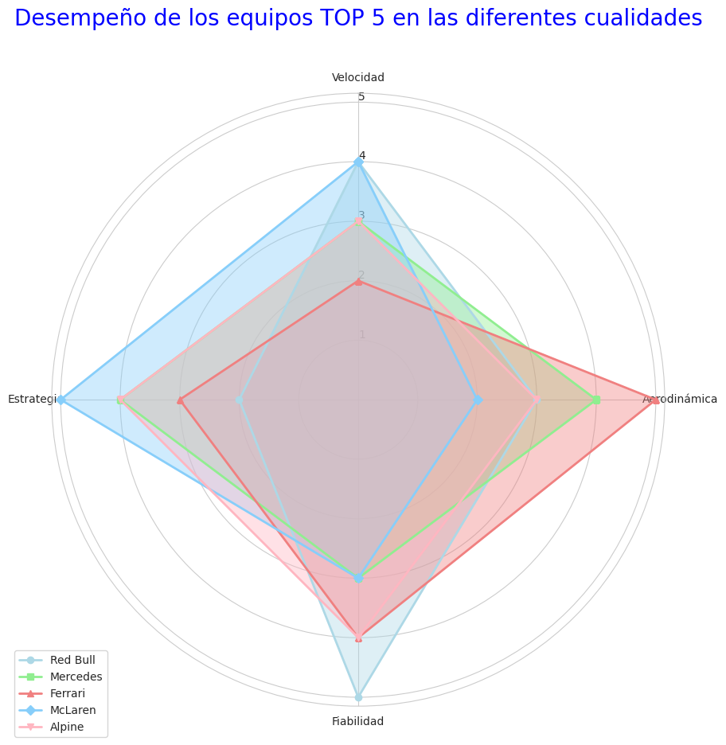

```python
# Gráfico 7: Radar para ver el desempeño de los equipos.
import matplotlib.pyplot as plt
import numpy as np
equipos = ['Red Bull', 'Mercedes', 'Ferrari', 'McLaren', 'Alpine']
categorias = ['Velocidad', 'Aerodinámica', 'Fiabilidad', 'Estrategia']
valores_equipo1 = [4, 3, 5, 2]
valores_equipo2 = [3, 4, 3, 4]
valores_equipo3 = [2, 5, 4, 3]
valores_equipo4 = [4, 2, 3, 5]
valores_equipo5 = [3, 3, 4, 4]
def grafico_radar(ax, equipos, categorias, valores, color, marker, nombre_equipo):
    num_categorias = len(categorias)
    angulos = np.linspace(0, 2 * np.pi, num_categorias, endpoint=False).tolist()

    valores += valores[:1]
    angulos += angulos[:1]

    ax.set_theta_offset(np.pi / 2)
    ax.set_theta_direction(-1)

    ax.set_rlabel_position(0)
    plt.xticks(angulos[:-1], categorias)

    ax.plot(angulos, valores, color=color, linewidth=2, linestyle='solid', label=nombre_equipo, marker=marker)
    ax.fill(angulos, valores, color=color, alpha=0.4)
fig, ax = plt.subplots(figsize=(10, 10), subplot_kw=dict(polar=True))

grafico_radar(ax, equipos, categorias, valores_equipo1, color='lightblue', marker='o', nombre_equipo='Red Bull')
grafico_radar(ax, equipos, categorias, valores_equipo2, color='lightgreen', marker='s', nombre_equipo='Mercedes')
grafico_radar(ax, equipos, categorias, valores_equipo3, color='lightcoral', marker='^', nombre_equipo='Ferrari')
grafico_radar(ax, equipos, categorias, valores_equipo4, color='lightskyblue', marker='D', nombre_equipo='McLaren')
grafico_radar(ax, equipos, categorias, valores_equipo5, color='lightpink', marker='v', nombre_equipo='Alpine')
ax.legend(loc='upper right', bbox_to_anchor=(0.1, 0.1))
plt.title('Desempeño de los equipos TOP 5 en las diferentes cualidades', size=20, color='blue', y=1.1)
plt.show()
```

**GRÁFICO 8:** ¿Cuál ha sido la evolución del rendimiento de diferentes grupos de edad a lo largo del tiempo?

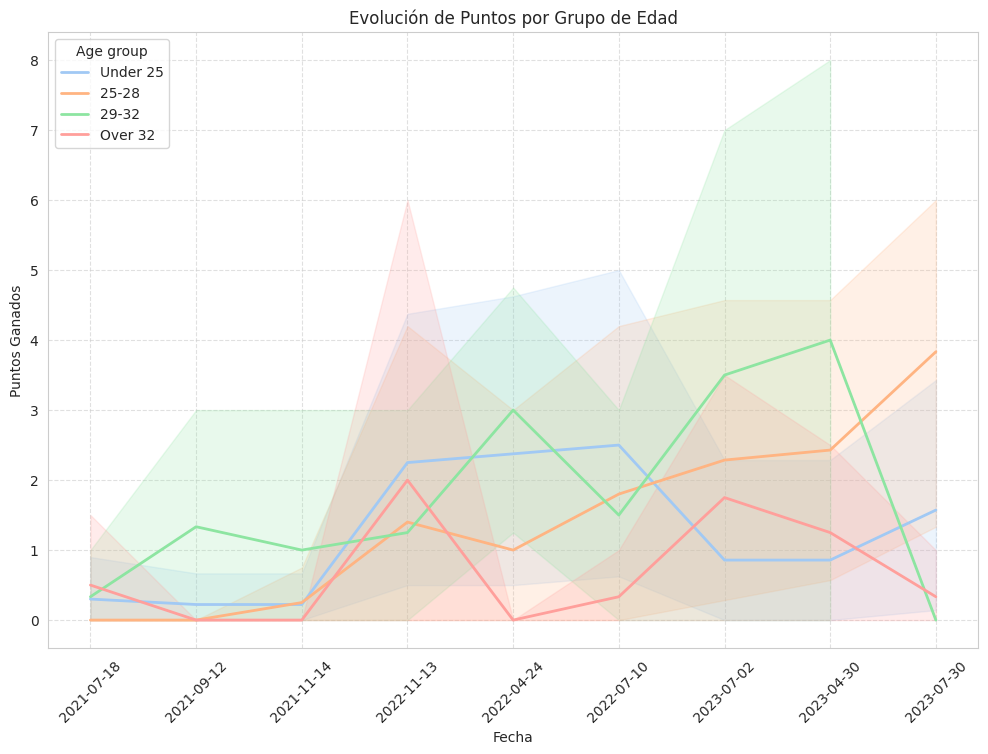

```python
# Gráfico 8: Diagrama de área para ver la evolución de puntos por los grupos de edad.
plt.figure(figsize=(12, 8))
sns.set_palette("pastel")
sns.set_style("whitegrid", {'axes.grid': False})

# Gráfico de líneas para la evolución de puntos por grupo de edad con líneas más gruesas
for age_group in sprint_details['Age group'].unique():
    subset = sprint_details[sprint_details['Age group'] == age_group]
    sns.lineplot(x='date', y='points_x', data=subset, label=age_group, linewidth=2)

plt.title('Evolución de Puntos por Grupo de Edad')
plt.xlabel('Fecha')
plt.ylabel('Puntos Ganados')
plt.legend(title='Age group', loc='upper left')
plt.xticks(rotation=45)
plt.grid(True, linestyle='--', alpha=0.6)
plt.show()
```

**GRÁFICO 9:** ¿Cómo se distribuyen los puntos en función de la posición en el grid para diferentes grupos de edad?

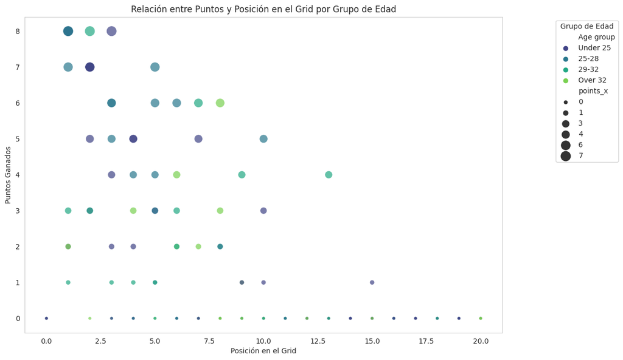

```python
# Gráfico 9: Burbujas para ver la relación entre los puntos y la posición en el grid para cada grupo de edad.
plt.figure(figsize=(12, 8))
x = sprint_details['grid_x']
y = sprint_details['points_x']
hue = sprint_details['Age group']
sns.scatterplot(x=x, y=y, hue=hue, size=y, sizes=(20, 200), palette='viridis', alpha=0.7)
plt.title('Relación entre Puntos y Posición en el Grid por Grupo de Edad')
plt.xlabel('Posición en el Grid')
plt.ylabel('Puntos Ganados')
plt.legend(title='Grupo de Edad', loc='upper right', bbox_to_anchor=(1.25, 1))
plt.show()
```

**GRÁFICO 10:** ¿Cómo se distribuyen los puntos ganados según el estado final de la carrera y piloto?

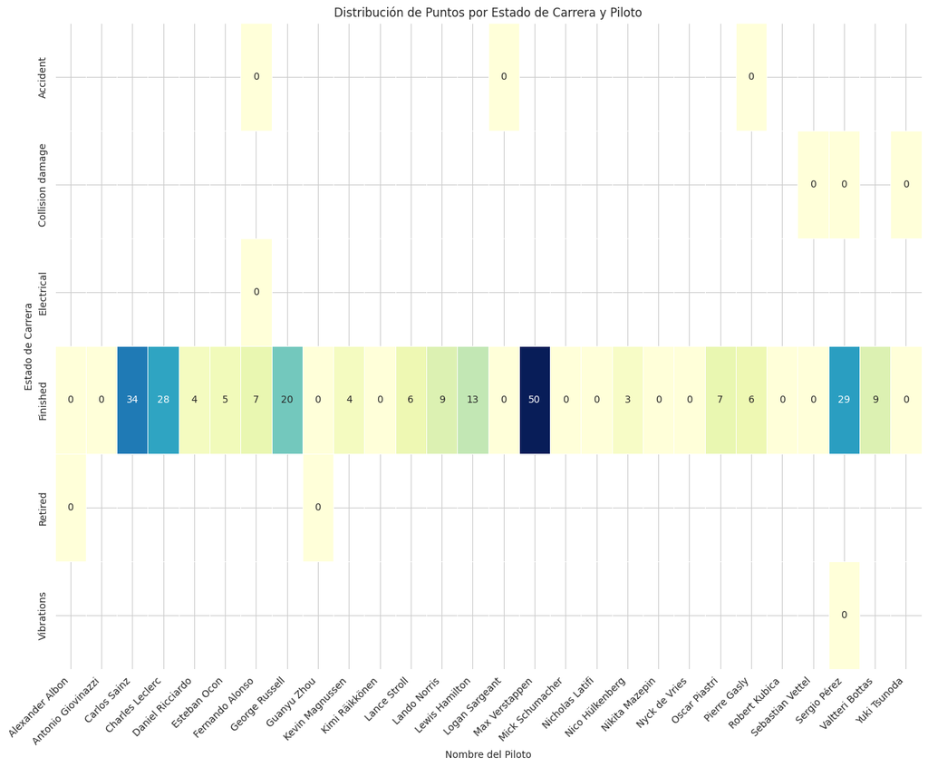

```python
# Gráfico 10: Mapa de calor (heatmap) para la distribución de puntos por estado de carrera y piloto

plt.figure(figsize=(16, 12))  # Ajustar el tamaño de la figura

sns.set_palette("pastel")
sns.set_style("whitegrid")

heatmap_data = sprint_details.pivot_table(index='status', columns='fullname', values='points_x', aggfunc='sum')
sns.heatmap(heatmap_data, cmap='YlGnBu', annot=True, fmt='g', linewidths=.5, cbar=False)  # Desactivar la barra de colores

plt.title('Distribución de Puntos por Estado de Carrera y Piloto')
plt.xlabel('Nombre del Piloto')
plt.ylabel('Estado de Carrera')

# Girar el eje horizontal 45 grados
plt.xticks(rotation=45, ha='right')  # Alinear las etiquetas a la derecha

plt.show()
```

**GRÁFICO 11:** ¿Cómo se distribuyen los puntos ganados según el estado final de la carrera y constructor?

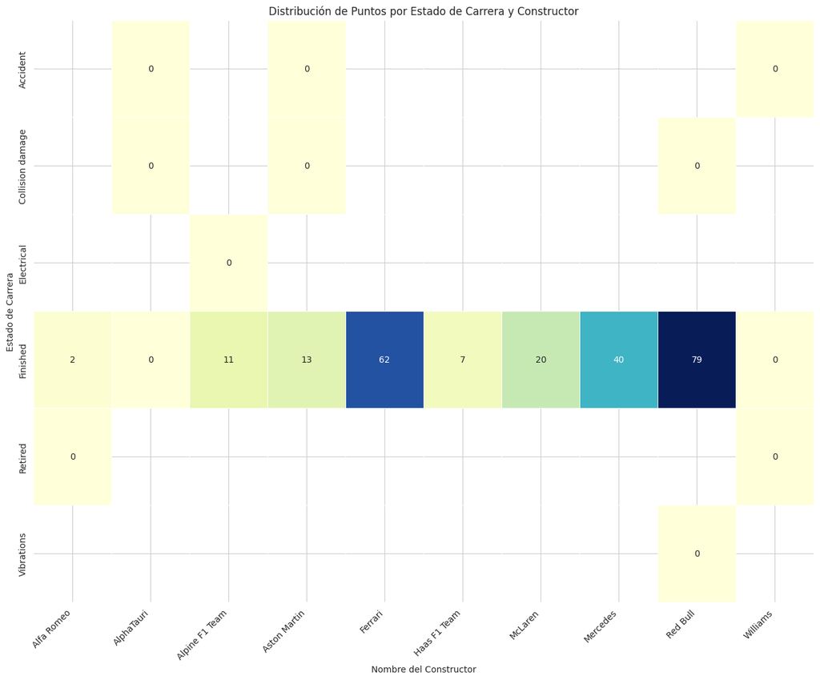

```python
# Gráfico 11: Mapa de calor (heatmap) para la distribución de puntos por estado de carrera y constructor

plt.figure(figsize=(16, 12))  # Ajustar el tamaño de la figura

sns.set_palette("pastel")
sns.set_style("whitegrid")

heatmap_data = sprint_details.pivot_table(index='status', columns='constructorName', values='points_x', aggfunc='sum')
sns.heatmap(heatmap_data, cmap='YlGnBu', annot=True, fmt='g', linewidths=.5, cbar=False)  # Desactivar la barra de colores

plt.title('Distribución de Puntos por Estado de Carrera y Constructor')
plt.xlabel('Nombre del Constructor')
plt.ylabel('Estado de Carrera')

# Girar el eje horizontal 45 grados
plt.xticks(rotation=45, ha='right')  # Alinear las etiquetas a la derecha

plt.show()
```

**GRÁFICO 12:** ¿Cuáles son los pilotos más fiables, teniendo en cuenta el número de carreras finalizadas y el número total de puntos ganados?

[figure not shown]

```python
# Gráfico 12: Gráfico de barras horizontales con los pilotos más fiables

# Filtrar el DataFrame para obtener solo los pilotos que han terminado carreras
finished_races = sprint_details[sprint_details['status'] == 'Finished']

# Calcular la cantidad de carreras terminadas por piloto
finished_race_counts = finished_races['fullname'].value_counts().reset_index()
finished_race_counts.columns = ['Piloto', 'Cantidad de Carreras Terminadas']

# Calcular los puntos totales ganados por piloto
total_points = finished_races.groupby('fullname')['points_x'].sum().reset_index()
total_points.columns = ['Piloto', 'Puntos Totales']

# Combinar los DataFrames
combined_data = pd.merge(finished_race_counts, total_points, on='Piloto')

# Ordenar los pilotos por la cantidad total de carreras terminadas
combined_data = combined_data.sort_values(by='Cantidad de Carreras Terminadas', ascending=False)

# Crear un gráfico de barras para mostrar los pilotos que han terminado la mayoría de las carreras
plt.figure(figsize=(12, 8))
sns.set_palette("pastel")
sns.set_style("whitegrid")

ax = sns.barplot(data=combined_data.head(10), x='Cantidad de Carreras Terminadas', y='Piloto', palette='pastel', orient='h')

plt.title('Pilotos Más Fiables')
plt.xlabel('Cantidad de Carreras Terminadas')
plt.ylabel('Nombre del Piloto')

# Agregar el número de puntos totales ganados en cada barra
for i, row in combined_data.head(10).iterrows():
    ax.text(row['Cantidad de Carreras Terminadas'] + 1, i, f'{row["Puntos Totales"]} puntos', va='center', fontsize=10)

# Limitar el eje x hasta 10
plt.xlim(0, 10)

plt.show()
```

La aplicación estratégica de estas técnicas de visualización permitió una inmersión profunda en los datos de la Fórmula 1, proporcionando respuestas detalladas a preguntas específicas formuladas durante el análisis exploratorio.

La variedad de gráficos seleccionados demuestra la versatilidad de las herramientas de visualización para revelar patrones, relaciones y tendencias, brindando así una perspectiva enriquecedora sobre el rendimiento en el mundo de las carreras automovilísticas.

```python
from google.colab import drive

drive.mount('/content/drive')
```

```python
import os

# Cambia al directorio donde se encuentra tu cuaderno
os.chdir('/content/drive/My Drive/Colab Notebooks')
```

```python
!jupyter nbconvert PRA2_jmarroyo.ipynb --to html
```

```
[NbConvertApp] Converting notebook PRA2_jmarroyo.ipynb to html
[NbConvertApp] Writing 1509759 bytes to PRA2_jmarroyo.html
```